# Decorrelation-Based SOTA: Parkinsons

Jose Tamez

2024-03-04

# 1 Effect of UPSTM-Based Decorrelation on ML Performance

### 1.0.1 Loading the libraries

```r
library("FRESA.CAD")
library(readxl)
library(igraph)
library(umap)
library(tsne)
library(entropy)

op <- par(no.readonly = TRUE)
pander::panderOptions('digits', 3)
pander::panderOptions('table.split.table', 400)
pander::panderOptions('keep.trailing.zeros',TRUE)
source("C:/Users/jtame/Documents/GitHub/LatentBiomarkers/RMD/DecorrelationCV.R")
```

## 1.1 Material and Methods

## 1.2 The Data

```r
pd_speech_features <- as.data.frame(read_excel("~/GitHub/FCA/Data/pd_speech_features.xlsx",sheet = "pd_speech_features", range = "A2:ACB758"))
```

### 1.2.1 The Average of the Three Repetitions

Each subject had three repeated observations. Here I’ll use the average of the three experiments per subject.

```r
rep1Parkison <- subset(pd_speech_features,RID==1)
rownames(rep1Parkison) <- rep1Parkison$id
rep1Parkison$id <- NULL
rep1Parkison$RID <- NULL
rep1Parkison[,1:ncol(rep1Parkison)] <- sapply(rep1Parkison,as.numeric)

rep2Parkison <- subset(pd_speech_features,RID==2)
rownames(rep2Parkison) <- rep2Parkison$id
rep2Parkison$id <- NULL
rep2Parkison$RID <- NULL
rep2Parkison[,1:ncol(rep2Parkison)] <- sapply(rep2Parkison,as.numeric)

rep3Parkison <- subset(pd_speech_features,RID==3)
rownames(rep3Parkison) <- rep3Parkison$id
rep3Parkison$id <- NULL
rep3Parkison$RID <- NULL
rep3Parkison[,1:ncol(rep3Parkison)] <- sapply(rep3Parkison,as.numeric)

whof <- !(colnames(rep1Parkison) %in% c("gender","class"));
avgParkison <- rep1Parkison;
avgParkison[,whof] <- (rep1Parkison[,whof] + rep2Parkison[,whof] + rep3Parkison[,whof])/3


signedlog <- function(x) { return (sign(x)*log(abs(1.0e12*x)+1.0))}
whof <- !(colnames(avgParkison) %in% c("gender","class"));
avgParkison[,whof] <- signedlog(avgParkison[,whof])
```

#### 1.2.1.1 Standarize the names for the reporting

```r
studyName <- "Parkinsons"
dataframe <- avgParkison
outcome <- "class"
tfrac <- 0.80
nLoops <- 50

needScaling <- TRUE
IDSample <- FALSE
thro <- 0.8
```

## 1.3 CV Analysis and report

### 1.3.1 Libraries

```r
library(xgboost)
library("vioplot")
```

## 1.4 XGB interface

```r
s3xgb <- function(formula=formula,data=NULL,...)
{
  if (inherits(formula, "character"))
    {
        formula <- formula(formula);
    }
    dependent <- all.vars(formula)
    Outcome = dependent[1];

  thexbcol <- colnames(data)[(colnames(data) != Outcome)]
  xbst <- xgboost(data = as.matrix(data[,thexbcol]), label = data[,Outcome],
                max_depth = 30, eta = 0.05, nthread = 12, nrounds = 100,
                objective = "binary:logistic",verbose = 0)
  class(xbst) <- c("S3XBST",class(xbst))
  attr(xbst,"trainnames") <-  thexbcol
  return (xbst)
}
predict.S3XBST <- function(object,...)
{
  parameters <- list(...);
    testData <- parameters[[1]];
    class(object) <- class(object)[2]
  pred <- predict(object,as.matrix(testData[,attr(object,"trainnames")]))
  return(pred)
}
```

## 1.5 SOTA Comparison to XGB, SVM and LASSO

### 1.5.1 XGB

```r
XBOOSTcv <- randomCV(dataframe,outcome,s3xgb,
                        trainFraction = tfrac,
                        repetitions = nLoops,
                        classSamplingType ="Ba")
```

……….10 Tested: 243 Avg. Selected: 0 Min Tests: 1 Max Tests: 10 Mean Tests: 6.17284 . MAD: 0.3013757

……….20 Tested: 251 Avg. Selected: 0 Min Tests: 1 Max Tests: 19 Mean Tests: 11.95219 . MAD: 0.2989632

……….30 Tested: 252 Avg. Selected: 0 Min Tests: 1 Max Tests: 28 Mean Tests: 17.85714 . MAD: 0.3001786

……….40 Tested: 252 Avg. Selected: 0 Min Tests: 3 Max Tests: 36 Mean Tests: 23.80952 . MAD: 0.2932359

……….50 Tested: 252 Avg. Selected: 0 Min Tests: 3 Max Tests: 44 Mean Tests: 29.7619 . MAD: 0.2908262

```r
XGBbs <- predictionStats_binary(XBOOSTcv$medianTest,"XGB: CV")
```

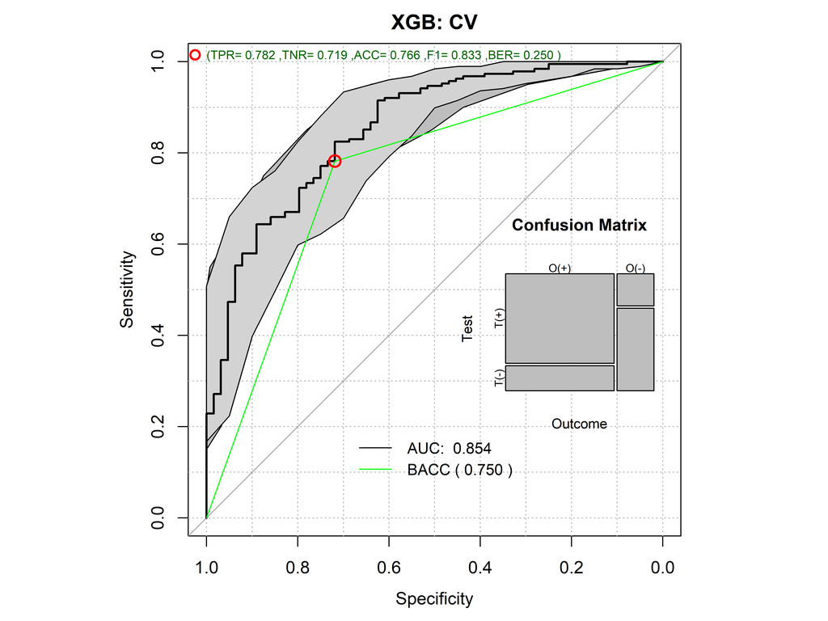

### 1.5.2 ILAA XGB

```r
ILAAXGBcv <- randomCV(fittingFunction = filteredFit,
                     trainSampleSets = XBOOSTcv$trainSamplesSets,
                     fitmethod = s3xgb,
                      filtermethod = NULL,
                    DECOR = TRUE,
                    DECOR.control=list(thr=thro)
                    )
```

……….10 Tested: 243 Avg. Selected: 753 Min Tests: 1 Max Tests: 10 Mean Tests: 6.17284 . MAD: 0.2776831

……….20 Tested: 251 Avg. Selected: 753 Min Tests: 1 Max Tests: 19 Mean Tests: 11.95219 . MAD: 0.2797226

……….30 Tested: 252 Avg. Selected: 753 Min Tests: 1 Max Tests: 28 Mean Tests: 17.85714 . MAD: 0.2809944

……….40 Tested: 252 Avg. Selected: 753 Min Tests: 3 Max Tests: 36 Mean Tests: 23.80952 . MAD: 0.2752105

……….50 Tested: 252 Avg. Selected: 753 Min Tests: 3 Max Tests: 44 Mean Tests: 29.7619 . MAD: 0.2770792

```r
ILAAXGBbs <- predictionStats_binary(ILAAXGBcv$medianTest,"ILAA-XGB: CV")
```

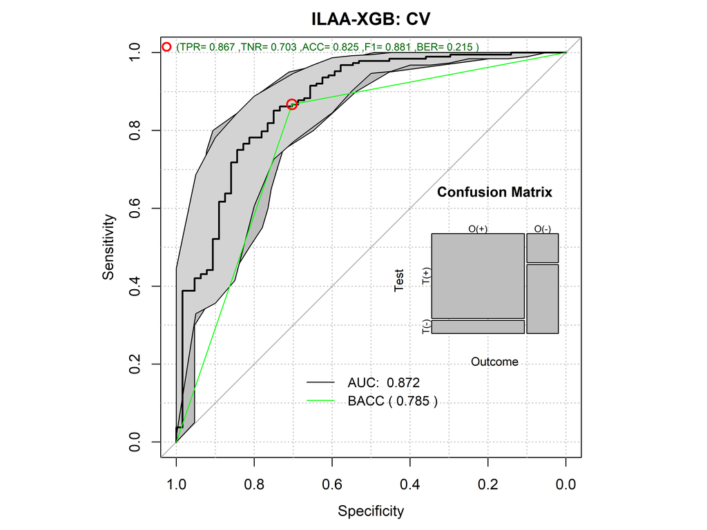

### 1.5.3 LASSO

```r
LASSOcv <- randomCV(fittingFunction = LASSO_MIN,
                     trainSampleSets = XBOOSTcv$trainSamplesSets,
                    family="binomial")
```

……….10 Tested: 243 Avg. Selected: 24.6 Min Tests: 1 Max Tests: 10 Mean Tests: 6.17284 . MAD: 0.3363859

……….20 Tested: 251 Avg. Selected: 21.9 Min Tests: 1 Max Tests: 19 Mean Tests: 11.95219 . MAD: 0.3365634

……….30 Tested: 252 Avg. Selected: 20.86667 Min Tests: 1 Max Tests: 28 Mean Tests: 17.85714 . MAD: 0.3396893

……….40 Tested: 252 Avg. Selected: 20.6 Min Tests: 3 Max Tests: 36 Mean Tests: 23.80952 . MAD: 0.3430018

……….50 Tested: 252 Avg. Selected: 22.5 Min Tests: 3 Max Tests: 44 Mean Tests: 29.7619 . MAD: 0.3387059

```r
LASSObs <- predictionStats_binary(LASSOcv$medianTest,"LASSO: CV")
```

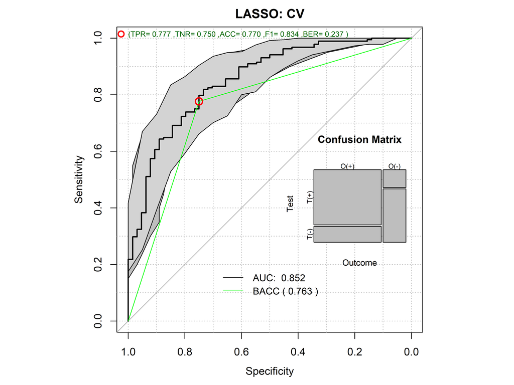

### 1.5.4 ILAA LASSO

```r
ILAALASSOcv <- randomCV(fittingFunction = filteredFit,
                     trainSampleSets = XBOOSTcv$trainSamplesSets,
                     fitmethod = LASSO_MIN,
                      filtermethod = NULL,
                    DECOR = TRUE,
                    DECOR.control=list(thr=thro),
                    family="binomial")
```

……….10 Tested: 243 Avg. Selected: 26.6 Min Tests: 1 Max Tests: 10 Mean Tests: 6.17284 . MAD: 0.3433136

……….20 Tested: 251 Avg. Selected: 25.75 Min Tests: 1 Max Tests: 19 Mean Tests: 11.95219 . MAD: 0.3421789

……….30 Tested: 252 Avg. Selected: 24.5 Min Tests: 1 Max Tests: 28 Mean Tests: 17.85714 . MAD: 0.3408322

……….40 Tested: 252 Avg. Selected: 24.825 Min Tests: 3 Max Tests: 36 Mean Tests: 23.80952 . MAD: 0.3446627

……….50 Tested: 252 Avg. Selected: 25.36 Min Tests: 3 Max Tests: 44 Mean Tests: 29.7619 . MAD: 0.3474393

```r
ILAALASSObs <- predictionStats_binary(ILAALASSOcv$medianTest,"ILLA-LASSO: CV")
```

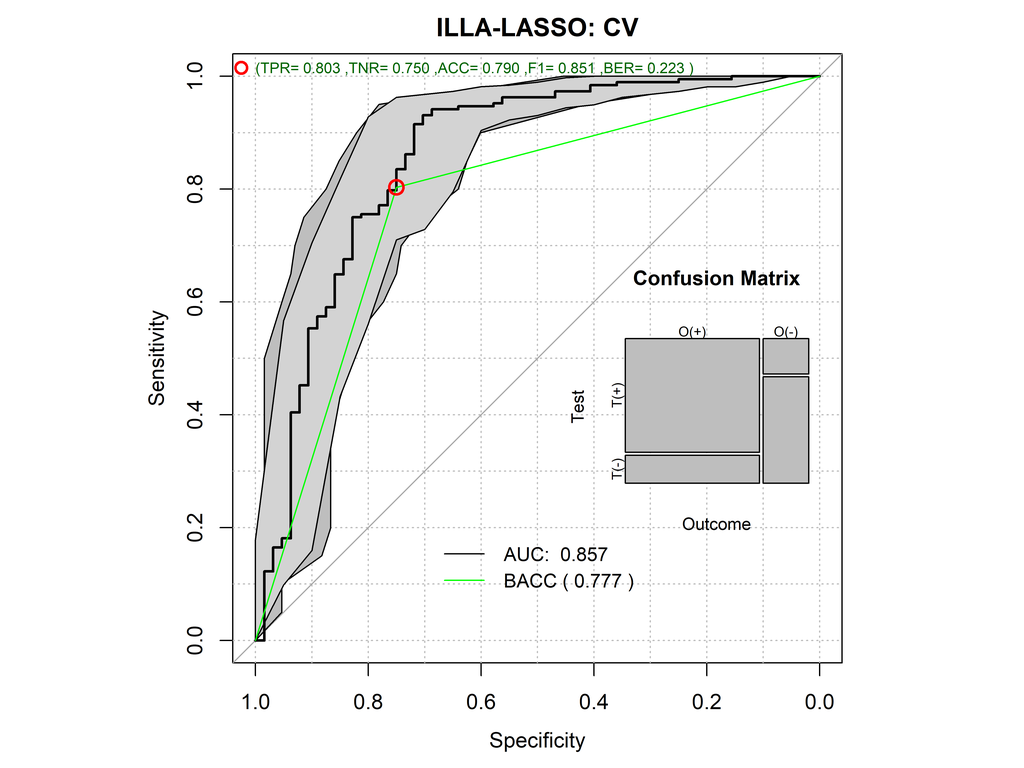

### 1.5.5 SVM

```r
SVMcv <- randomCV(fittingFunction = filteredFit,
                  trainSampleSets = XBOOSTcv$trainSamplesSets,
                  asFactor = TRUE,
                  filtermethod = multivariate_BinEnsemble,
                  filtermethod.control=NULL,
                  probability=TRUE)
```

…………….10 Tested: 243 Avg. Selected: 291.1 Min Tests: 1 Max Tests: 10 Mean Tests: 6.17284 . MAD: 0.3404446

………..20 Tested: 251 Avg. Selected: 276.05 Min Tests: 1 Max Tests: 19 Mean Tests: 11.95219 . MAD: 0.3338865

…………30 Tested: 252 Avg. Selected: 275.6333 Min Tests: 1 Max Tests: 28 Mean Tests: 17.85714 . MAD: 0.3341312

……………40 Tested: 252 Avg. Selected: 274.825 Min Tests: 3 Max Tests: 36 Mean Tests: 23.80952 . MAD: 0.3340578

……………50 Tested: 252 Avg. Selected: 275.86 Min Tests: 3 Max Tests: 44 Mean Tests: 29.7619 . MAD: 0.3336694

```r
SVMbs <- predictionStats_binary(SVMcv$medianTest,"SVM: CV")
```

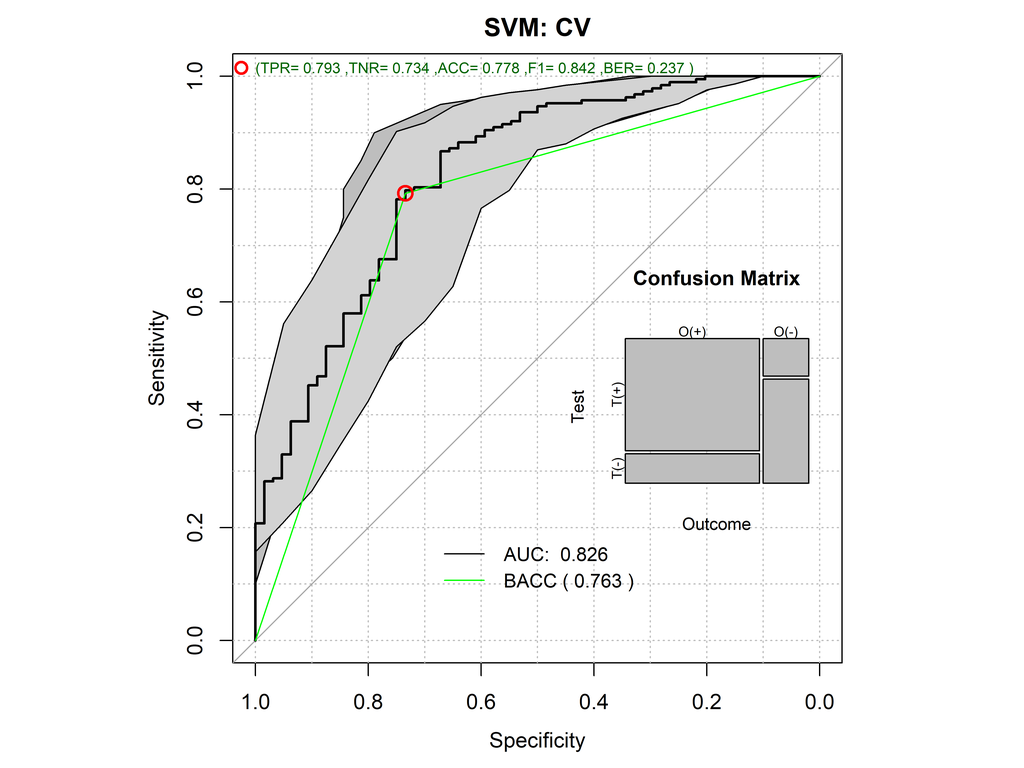

### 1.5.6 ILAAA SVM

```r
ILLASVMcv <- randomCV(dataframe,outcome,fittingFunction = filteredFit,
                  trainSampleSets = XBOOSTcv$trainSamplesSets,
                  asFactor = TRUE,
                  DECOR = TRUE,
                  DECOR.control=list(thr=thro),
                  filtermethod = multivariate_BinEnsemble,
                  filtermethod.control=NULL,
                  probability=TRUE)
```

……………..10 Tested: 243 Avg. Selected: 226.2 Min Tests: 1 Max Tests: 10 Mean Tests: 6.17284 . MAD: 0.3213945

……………..20 Tested: 251 Avg. Selected: 210.2 Min Tests: 1 Max Tests: 19 Mean Tests: 11.95219 . MAD: 0.3204776

……………..30 Tested: 252 Avg. Selected: 213.8333 Min Tests: 1 Max Tests: 28 Mean Tests: 17.85714 . MAD: 0.3185395

………………..40 Tested: 252 Avg. Selected: 211.35 Min Tests: 3 Max Tests: 36 Mean Tests: 23.80952 . MAD: 0.3201245

………………50 Tested: 252 Avg. Selected: 210.5 Min Tests: 3 Max Tests: 44 Mean Tests: 29.7619 . MAD: 0.320592

```r
ILLASVMbs <- predictionStats_binary(ILLASVMcv$medianTest,"ILLA-SVM: CV")
```

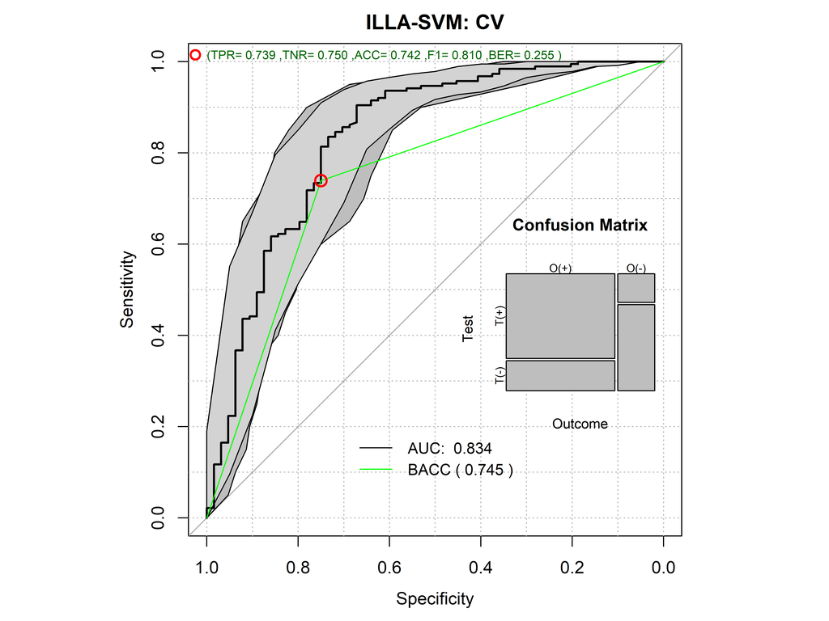

## 1.6 The Reports

```r
par(op)
AUCTABLE <- rbind(
                  XGBbs$aucs,
                  SVMbs$aucs,
                  LASSObs$aucs,
                  ILAAXGBbs$aucs,
                  ILLASVMbs$aucs,
                  ILAALASSObs$aucs
                  )
colnames(AUCTABLE) <- c("Median","Lower","Upper")
rownames(AUCTABLE) <- c("XGB","SVM","LASSO",
                        "ILAA-XGB","ILAA-SVM","ILAA-LASSO")

pander::pander(AUCTABLE)
```

|  | Median | Lower | Upper |
| --- | --- | --- | --- |
| **XGB** | 0.854 | 0.801 | 0.907 |
| **SVM** | 0.826 | 0.766 | 0.887 |
| **LASSO** | 0.852 | 0.799 | 0.905 |
| **ILAA-XGB** | 0.872 | 0.818 | 0.925 |
| **ILAA-SVM** | 0.834 | 0.770 | 0.898 |
| **ILAA-LASSO** | 0.857 | 0.795 | 0.919 |

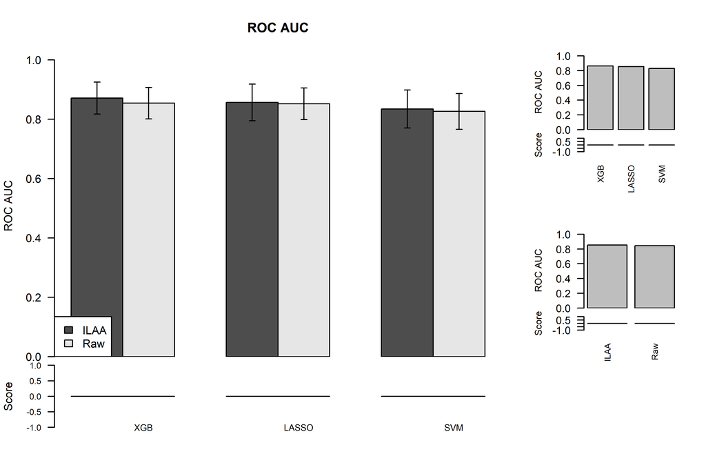

```r
thesets <- c("XGB","SVM","LASSO")
themethod <- c("Raw","ILAA")
pauc <- barPlotCiError(AUCTABLE,
               "ROC AUC",
               thesets=thesets,
               themethod=themethod,
               main="ROC AUC",
               angle=0,
               offsets=c(0.1,1.0),
               scoreDirection=">",args.legend=list(x="bottomleft"))

par(op)
```

```r
BERTABLE <- rbind(
                  XGBbs$berror,
                  SVMbs$berror,
                  LASSObs$berror,
                  ILAAXGBbs$berror,
                  ILLASVMbs$berror,
                  ILAALASSObs$berror
                  )


colnames(BERTABLE) <- colnames(AUCTABLE)
rownames(BERTABLE) <- rownames(AUCTABLE)

pander::pander(BERTABLE)
```

|  | Median | Lower | Upper |
| --- | --- | --- | --- |
| **XGB** | 0.250 | 0.188 | 0.312 |
| **SVM** | 0.237 | 0.173 | 0.300 |
| **LASSO** | 0.235 | 0.180 | 0.297 |
| **ILAA-XGB** | 0.215 | 0.154 | 0.279 |
| **ILAA-SVM** | 0.255 | 0.190 | 0.317 |
| **ILAA-LASSO** | 0.223 | 0.162 | 0.288 |

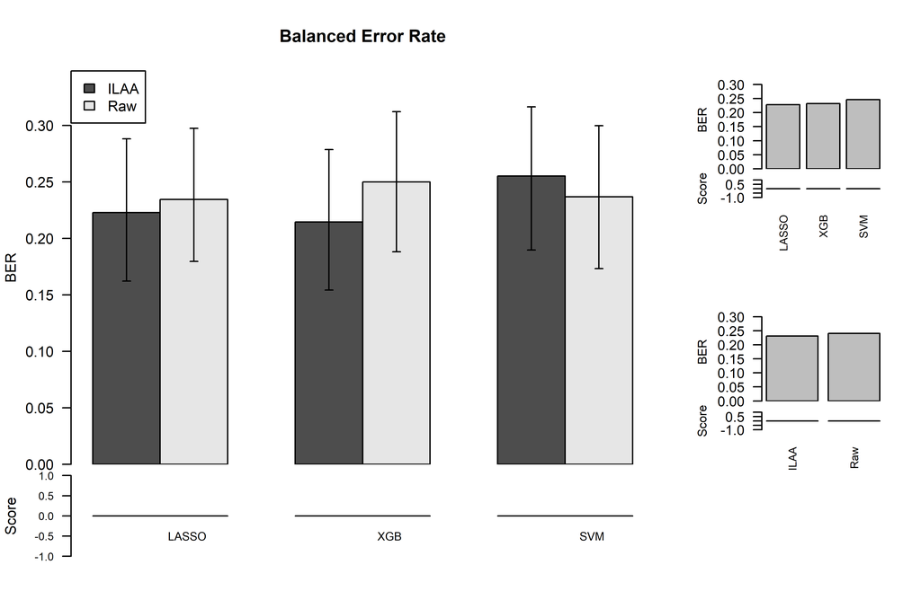

```r
pber <- barPlotCiError(BERTABLE,
               "BER",
               thesets=thesets,
               themethod=themethod,
               main="Balanced Error Rate",
               angle=0,
               offsets=c(0.1,0.5),
               scoreDirection="<",args.legend=list(x="topleft"))
```

### 1.6.1 Saving ALL

```r
save.image(paste("SOTACV_analyiss",studyName,".RData",sep="_"))
```